# DATA 607 Week 7 Assignment

Gabriel Santos

2022-10-15

# Working With XML and JSON in R

# Assignment Description

Pick three of your favorite books on one of your favorite subjects. At least one of the books should have more than one author. For each book, include the title, authors, and two or three other attributes that you find interesting.

Take the information that you’ve selected about these three books, and separately create three files which store the book’s information in HTML (using an html table), XML, and JSON formats (e.g. “books.html”, “books.xml”, and “books.json”). To help you better understand the different file structures, I’d prefer that you create each of these files “by hand” unless you’re already very comfortable with the file formats.

Write R code, using your packages of choice, to load the information from each of the three sources into separate R data frames. Are the three data frames identical? Your deliverable is the three source files and the R code. If you can, package your assignment solution up into an .Rmd file and publish to rpubs.com. [This will also require finding a way to make your three text files accessible from the web].

## Data of Three Books

Three books with six attributes are selected for this assignment. A brief view of data is as below:

| Title | Author | Publisher | Year | Edition | ISBN |
| --- | --- | --- | --- | --- | --- |
| Automated Data Collection with R | Simon Munzert, Christian Rubba, Peter Meißner, Dominic Nyhuis | John Wiley & Sons, Ltd | 2015 | 1st | 978-1-118-83481-7 |
| Data Science for Business | Foster Provost, Tom Fawcett | O’Reilly Media, Inc | 2013 | 1st | 978-1-449-36132-7 |
| Bayesian Data Analysis | Andrew Gelman, John B. Carlin, Hal S. Stern, David B. Dunson, Aki Vehtari, Donald B. Rubin | CRC Press Taylor & Francis Group | 2013 | 3rd | 978-1-4398-9820-8 |

## R Packages

The following packages are used in this assignment

```r
library(tidyverse)
library(XML)
library(xml2)
library(rvest)
library(RCurl)
library(jsonlite)
```

## Create a HTML file

A HTML file is created with <title> ‘Three Books’ and a table under <body>. The source code is as below:

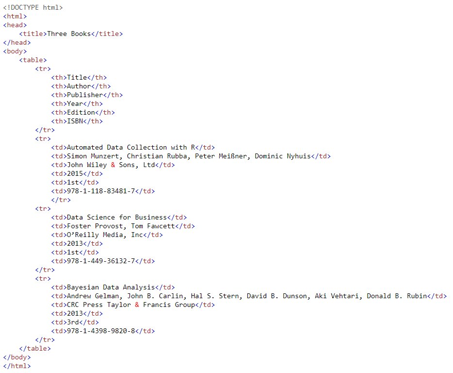

## Picture of the code interpreted by the browser:

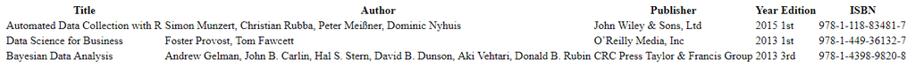

’’

## Load HTML Table into R

The following actions are performed to load the HTML table into R as data frame:

1. use get `getURL` function to extract the link of the html file.
2. parse the html file with `read_html` function.
3. use `html_table` function to extract a list of tables if any from the html file and convert the tables into dataframes.
4. There is only one table in the html file, therefore the first element of the list is returned.

```r
# HTML
url <- getURL('https://raw.githubusercontent.com/GabrielSantos33/DATA607-Assignment-8/main/Three%20Books.htm')
df_HTML <- url %>%
  read_html(encoding = 'UTF-8') %>%
  html_table(header = NA, trim = TRUE) %>%
  .[[1]]

df_HTML
```

```
## # A tibble: 3 × 6
##   Title                            Author            Publi…¹  Year Edition ISBN
##   <chr>                            <chr>             <chr>   <int> <chr>   <chr>
## 1 Automated Data Collection with R Simon Munzert, C… John W…  2015 1st     978-…
## 2 Data Science for Business        Foster Provost, … O’Reil…  2013 1st     978-…
## 3 Bayesian Data Analysis           Andrew Gelman, J… CRC Pr…  2013 3rd     978-…
## # … with abbreviated variable name ¹Publisher
```

```r
str(df_HTML)
```

```
## tibble [3 × 6] (S3: tbl_df/tbl/data.frame)
##  $ Title    : chr [1:3] "Automated Data Collection with R" "Data Science for Business" "Bayesian Data Analysis"
##  $ Author   : chr [1:3] "Simon Munzert, Christian Rubba, Peter Meißner, Dominic Nyhuis" "Foster Provost, Tom Fawcett" "Andrew Gelman, John B. Carlin, Hal S. Stern, David B. Dunson, Aki Vehtari, Donald B. Rubin"
##  $ Publisher: chr [1:3] "John Wiley & Sons, Ltd" "O’Reilly Media, Inc" "CRC Press Taylor & Francis Group"
##  $ Year     : int [1:3] 2015 2013 2013
##  $ Edition  : chr [1:3] "1st" "1st" "3rd"
##  $ ISBN     : chr [1:3] "978-1-118-83481-7" "978-1-449-36132-7" "978-1-4398-9820-8"
```

## Picture of the XML source code:

[figure not shown]

’’

## Load XML Table into R

```r
#XML 1
url <- getURL('https://raw.githubusercontent.com/GabrielSantos33/DATA607-Assignment-8/main/Three%20Books.xml')
df_XML <- url %>%
  xmlParse() %>%
  xmlRoot() %>%
  xmlToDataFrame(stringsAsFactors = FALSE)
df_XML
```

```
##                              Title Author                        Publisher Year
## 1 Automated Data Collection with R                  John Wiley & Sons, Ltd 2015
## 2        Data Science for Business                     O’Reilly Media, Inc 2013
## 3           Bayesian Data Analysis        CRC Press Taylor & Francis Group 2013
##   Edition              ISBN
## 1     1st 978-1-118-83481-7
## 2     1st 978-1-449-36132-7
## 3     3rd 978-1-4398-9820-8
```

## JSON file picture source code:

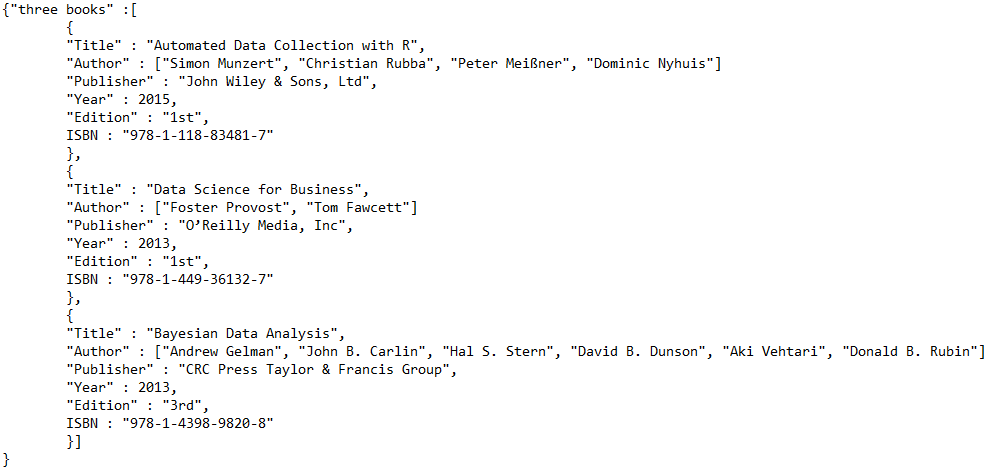

’’

## Load JSON table into R

1. Parse JSON into R as a list called `df_JSON`
2. Convert `df_JSON` to dataframe
3. reanme columns, removing prefix ‘three.books.’
4. The column `Author` contains lists of names of authors of each book, therefore concatename those names in each list as one single string in order to fit into column ‘Author’.

```r
#json
url <- getURL("https://raw.githubusercontent.com/GabrielSantos33/DATA607-Assignment-8/main/Three%20Books.json")
df_JSON <- url %>%
  fromJSON() %>%
  as.data.frame() %>%
  rename_all(funs(str_replace(., 'three\\.books\\.',''))) %>%
  mutate(Author = unlist(lapply(Author, function(x) str_c(x, collapse = ', '))))
df_JSON
```

```
##                              Title
## 1 Automated Data Collection with R
## 2        Data Science for Business
## 3           Bayesian Data Analysis
##                                                                                       Author
## 1                              Simon Munzert, Christian Rubba, Peter Meißner, Dominic Nyhuis
## 2                                                                Foster Provost, Tom Fawcett
## 3 Andrew Gelman, John B. Carlin, Hal S. Stern, David B. Dunson, Aki Vehtari, Donald B. Rubin
##                          Publisher Year Edition              ISBN
## 1           John Wiley & Sons, Ltd 2015     1st 978-1-118-83481-7
## 2              O’Reilly Media, Inc 2013     1st 978-1-449-36132-7
## 3 CRC Press Taylor & Francis Group 2013     3rd 978-1-4398-9820-8
```

```r
str(df_JSON)
```

```
## 'data.frame':    3 obs. of  6 variables:
##  $ Title    : chr  "Automated Data Collection with R" "Data Science for Business" "Bayesian Data Analysis"
##  $ Author   : chr  "Simon Munzert, Christian Rubba, Peter Meißner, Dominic Nyhuis" "Foster Provost, Tom Fawcett" "Andrew Gelman, John B. Carlin, Hal S. Stern, David B. Dunson, Aki Vehtari, Donald B. Rubin"
##  $ Publisher: chr  "John Wiley & Sons, Ltd" "O’Reilly Media, Inc" "CRC Press Taylor & Francis Group"
##  $ Year     : int  2015 2013 2013
##  $ Edition  : chr  "1st" "1st" "3rd"
##  $ ISBN     : chr  "978-1-118-83481-7" "978-1-449-36132-7" "978-1-4398-9820-8"
```

# Are the three data frames identical?

1. `df_HTML` Vs `df_XML`

```r
all.equal(df_HTML,df_XML)
```

```
## [1] "Attributes: < Component \"class\": Lengths (3, 1) differ (string compare on first 1) >"
## [2] "Attributes: < Component \"class\": 1 string mismatch >"
## [3] "Component \"Author\": 3 string mismatches"
## [4] "Component \"Year\": Modes: numeric, character"
## [5] "Component \"Year\": target is numeric, current is character"
```

```r
all.equal(df_HTML$Year, as.integer(df_XML$Year))
```

```
## [1] TRUE
```

2. `df_HTML` Vs `df_JSON`

```r
all.equal(df_HTML,df_JSON)
```

```
## [1] "Attributes: < Component \"class\": Lengths (3, 1) differ (string compare on first 1) >"
## [2] "Attributes: < Component \"class\": 1 string mismatch >"
```

3. `df_XML` Vs `df_JSON`

```r
all.equal(df_XML,df_JSON)
```

```
## [1] "Component \"Author\": 3 string mismatches"
## [2] "Component \"Year\": Modes: character, numeric"
## [3] "Component \"Year\": target is character, current is numeric"
```

```r
all.equal(as.integer(df_XML$Year), df_JSON$Year)
```

```
## [1] TRUE
```